# Project: No Show Data Analysis

- Introduction
- Data Wrangling
- Exploratory Data Analysis
- Conclusions

## Introduction

#### this dataset represents the data of the appointment of patients in a Hospital and whether they came in to the appointment or not. I am going to explore the data and try to see if there is a relation between the presense of the patients and some other information in the dataset

```python
import pandas as pd
import numpy as np
import matplotlib.pyplot as plt
```

## Data Wrangling

### General Properties

```python
df = pd.read_csv('noshowappointments-kagglev2-may-2016.csv')
df.head()
```

|  | PatientId | AppointmentID | Gender | ScheduledDay | AppointmentDay | Age | Neighbourhood | Scholarship | Hipertension | Diabetes | Alcoholism | Handcap | SMS_received | No-show |
| --- | --- | --- | --- | --- | --- | --- | --- | --- | --- | --- | --- | --- | --- | --- |
| 0 | 2.987250e+13 | 5642903 | F | 2016-04-29T18:38:08Z | 2016-04-29T00:00:00Z | 62 | JARDIM DA PENHA | 0 | 1 | 0 | 0 | 0 | 0 | No |
| 1 | 5.589978e+14 | 5642503 | M | 2016-04-29T16:08:27Z | 2016-04-29T00:00:00Z | 56 | JARDIM DA PENHA | 0 | 0 | 0 | 0 | 0 | 0 | No |
| 2 | 4.262962e+12 | 5642549 | F | 2016-04-29T16:19:04Z | 2016-04-29T00:00:00Z | 62 | MATA DA PRAIA | 0 | 0 | 0 | 0 | 0 | 0 | No |
| 3 | 8.679512e+11 | 5642828 | F | 2016-04-29T17:29:31Z | 2016-04-29T00:00:00Z | 8 | PONTAL DE CAMBURI | 0 | 0 | 0 | 0 | 0 | 0 | No |
| 4 | 8.841186e+12 | 5642494 | F | 2016-04-29T16:07:23Z | 2016-04-29T00:00:00Z | 56 | JARDIM DA PENHA | 0 | 1 | 1 | 0 | 0 | 0 | No |

```python
df.shape
```

```
(110527, 14)
```

```python
df.describe()
```

|  | PatientId | AppointmentID | Age | Scholarship | Hipertension | Diabetes | Alcoholism | Handcap | SMS_received |
| --- | --- | --- | --- | --- | --- | --- | --- | --- | --- |
| count | 1.105270e+05 | 1.105270e+05 | 110527.000000 | 110527.000000 | 110527.000000 | 110527.000000 | 110527.000000 | 110527.000000 | 110527.000000 |
| mean | 1.474963e+14 | 5.675305e+06 | 37.088874 | 0.098266 | 0.197246 | 0.071865 | 0.030400 | 0.022248 | 0.321026 |
| std | 2.560949e+14 | 7.129575e+04 | 23.110205 | 0.297675 | 0.397921 | 0.258265 | 0.171686 | 0.161543 | 0.466873 |
| min | 3.921784e+04 | 5.030230e+06 | -1.000000 | 0.000000 | 0.000000 | 0.000000 | 0.000000 | 0.000000 | 0.000000 |
| 25% | 4.172614e+12 | 5.640286e+06 | 18.000000 | 0.000000 | 0.000000 | 0.000000 | 0.000000 | 0.000000 | 0.000000 |
| 50% | 3.173184e+13 | 5.680573e+06 | 37.000000 | 0.000000 | 0.000000 | 0.000000 | 0.000000 | 0.000000 | 0.000000 |
| 75% | 9.439172e+13 | 5.725524e+06 | 55.000000 | 0.000000 | 0.000000 | 0.000000 | 0.000000 | 0.000000 | 1.000000 |
| max | 9.999816e+14 | 5.790484e+06 | 115.000000 | 1.000000 | 1.000000 | 1.000000 | 1.000000 | 4.000000 | 1.000000 |

##### we remove Patient ID and Appointment ID because it's belong to spicific Patient. Moreover, Schudule day and Appointment Day was removed because they are not consistent. I remove Neighbourhood because We don't know the distance

```python
df.drop(['PatientId','AppointmentID','ScheduledDay','AppointmentDay','Neighbourhood'], axis=1, inplace=True)
```

```python
df = df[df.Handcap <= 1]
```

```python
df = df[df.Age >=0]
```

```python
df.head()
```

|  | Gender | Age | Scholarship | Hipertension | Diabetes | Alcoholism | Handcap | SMS_received | No-show |
| --- | --- | --- | --- | --- | --- | --- | --- | --- | --- |
| 0 | F | 62 | 0 | 1 | 0 | 0 | 0 | 0 | No |
| 1 | M | 56 | 0 | 0 | 0 | 0 | 0 | 0 | No |
| 2 | F | 62 | 0 | 0 | 0 | 0 | 0 | 0 | No |
| 3 | F | 8 | 0 | 0 | 0 | 0 | 0 | 0 | No |
| 4 | F | 56 | 0 | 1 | 1 | 0 | 0 | 0 | No |

```python
df.describe()
```

|  | Age | Scholarship | Hipertension | Diabetes | Alcoholism | Handcap | SMS_received |
| --- | --- | --- | --- | --- | --- | --- | --- |
| count | 110327.000000 | 110327.000000 | 110327.000000 | 110327.000000 | 110327.000000 | 110327.000000 | 110327.000000 |
| mean | 37.070753 | 0.098281 | 0.196833 | 0.071605 | 0.030382 | 0.018509 | 0.321182 |
| std | 23.098052 | 0.297695 | 0.397607 | 0.257834 | 0.171638 | 0.134782 | 0.466932 |
| min | 0.000000 | 0.000000 | 0.000000 | 0.000000 | 0.000000 | 0.000000 | 0.000000 |
| 25% | 18.000000 | 0.000000 | 0.000000 | 0.000000 | 0.000000 | 0.000000 | 0.000000 |
| 50% | 37.000000 | 0.000000 | 0.000000 | 0.000000 | 0.000000 | 0.000000 | 0.000000 |
| 75% | 55.000000 | 0.000000 | 0.000000 | 0.000000 | 0.000000 | 0.000000 | 1.000000 |
| max | 115.000000 | 1.000000 | 1.000000 | 1.000000 | 1.000000 | 1.000000 | 1.000000 |

##### I have remove every Handcap larger then one because they represent small number of patients

```python
df.info()
```

```
<class 'pandas.core.frame.DataFrame'>
Int64Index: 110327 entries, 0 to 110526
Data columns (total 9 columns):
Gender          110327 non-null object
Age             110327 non-null int64
Scholarship     110327 non-null int64
Hipertension    110327 non-null int64
Diabetes        110327 non-null int64
Alcoholism      110327 non-null int64
Handcap         110327 non-null int64
SMS_received    110327 non-null int64
No-show         110327 non-null object
dtypes: int64(7), object(2)
memory usage: 8.4+ MB
```

##### No missing values, so we don't need make any more changes

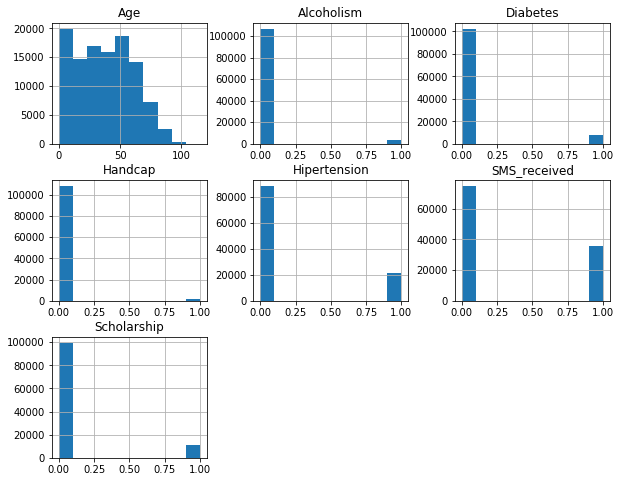

```python
df.hist(figsize=(10,8));
```

```python
new_label = list(df.columns)
new_label[8] = 'show'
df.columns = new_label
```

```python
df.head()
```

|  | Gender | Age | Scholarship | Hipertension | Diabetes | Alcoholism | Handcap | SMS_received | show |
| --- | --- | --- | --- | --- | --- | --- | --- | --- | --- |
| 0 | F | 62 | 0 | 1 | 0 | 0 | 0 | 0 | No |
| 1 | M | 56 | 0 | 0 | 0 | 0 | 0 | 0 | No |
| 2 | F | 62 | 0 | 0 | 0 | 0 | 0 | 0 | No |
| 3 | F | 8 | 0 | 0 | 0 | 0 | 0 | 0 | No |
| 4 | F | 56 | 0 | 1 | 1 | 0 | 0 | 0 | No |

```python
# replace the Yes and No with 1 and 0 to make it easier to compare
df['show'].replace(['No','Yes'],['1','0'], inplace = True)
```

```python
#convert String to int
df['show'] = df['show'].astype(int)
```

```python
# to make the comparsions easier
Came = df.show == 1
NotCame= df.show == 0
```

## Exploratory Data Analysis

### Does the perosons who receive SMS message show in the appointments ?

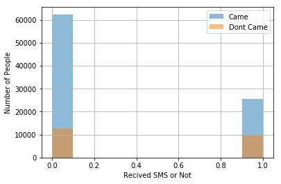

```python
# PLOT of the presons who came and did not came and if they receive SMS message or not
df.SMS_received[Came].hist(alpha=0.5, label='Came')
df.SMS_received[NotCame].hist(alpha=0.5, label='Dont Came')
plt.xlabel('Recived SMS or Not')
plt.ylabel('Number of People')
plt.legend();
```

### Does the age affect the presense of the patients

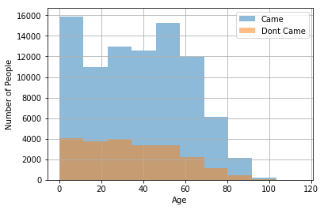

```python
df.Age[Came].hist(alpha=0.5, label='Came')
df.Age[NotCame].hist(alpha=0.5, label='Dont Came')
plt.xlabel('Age')
plt.ylabel('Number of People')
plt.legend();
```

##### We can Observers that the Age did not effect the presense of the patients. the Majority of the patients who came and did not came are between 0 - 60. so we cannot say the age is the reason of the presense or absenes of the patients.

## Conclusions

> **Limitation:**
> 1. The Scheduled Day and Appointment Day is not consistent and we cannot use it.
> 2. We don't know the distance between the address of the patients and the hospital we cannot use it to make observations.